# NBA Data Analysis

**Part 1)** Logistic Regression for Win Probability  
**Part 2)** Summarize the Team Data for Season 2018-2019

### Logistic Regression for Win Predictibility

In this report I am trying to predict win probability of a team in a given match  
To build a Good Logistic Regression Model, I am trying to build a good feature set  
The feature set containes:  
1) Home Team vs Visiter Team  
2) Perfomrance by team in last season (Win/Losses)  
3) Performance in this season till now (Win/Losses)  
4) Points Used Till Mid-Time

The abvoe feature set is used, as it available pre-match, and we are trying to predict the win probability in two steps  
1) Before the Start of Match based on first 3 stats,  
2) After Half Time by using 2 QTRs data, and also transforming into mean Diff by first half

```python
import pandas as pd
from nba_py import team
from nba_py import game
from nba_py import Scoreboard
from sklearn.linear_model import LogisticRegression
from sklearn.model_selection import train_test_split
from sklearn import preprocessing
from sklearn.metrics import classification_report
import warnings
warnings.filterwarnings('ignore')
```

```python
import matplotlib.pyplot as plt
%matplotlib inline
import seaborn
from matplotlib import rcParams
from bokeh.plotting import figure, output_file, show
from bokeh.io import output_notebook
from bokeh.layouts import column
output_notebook()
```

```python
# Step 1: Get all teams list
df = team.TeamList(league_id='00')
df = df.info()
#df.head()
```

```python
# Selecting team with MAX_YEAR 2019
df = df.where(df.MAX_YEAR == 2019)
df = df.dropna()
```

### Adding Data From Past Season

1) Adding last season last 20 game Win percentage of the team  
2) Adding Last season win percentage of the team

```python
# Finding Stats for a team based on their Previous Season (Last 20 Games) and adding it to column
df['LAST_20_WIN_PCT'] =  0
for i in range(len(df)):
    data = team.TeamLastNGamesSplits(team_id=int(df['TEAM_ID'].iloc[i]), measure_type='Base', per_mode='PerGame',
                               plus_minus='N', pace_adjust='N', rank='N', league_id='00',
                               season='2017-18', season_type='Regular Season', po_round='0',
                               outcome='', location='', month='0', season_segment='', date_from='',
                               date_to='', opponent_team_id='0', vs_conference='', vs_division='',
                               game_segment='', period='0', shot_clock_range='', last_n_games='0')
    data = data.last20()
    df['LAST_20_WIN_PCT'].iloc[i] = data['W_PCT'].values[0]
```

```python
# Adding Win Pct from Last season and adding it to team data
df['PAST_WIN_PCT'] =  0
for i in range(len(df)):
    data = team.TeamSummary(team_id=int(df['TEAM_ID'].iloc[i]), season='2017-18', league_id='00', season_type='Regular Season')
    data = data.info()
    df['PAST_WIN_PCT'].iloc[i] = data['PCT'].values[0]
```

```python
#print(df)
#df.to_csv('team_stats_2019.csv')
#df_team = pd.read_csv('team_stats_2019.csv',index_col=0)
#df_team.head()
```

```python
# Previously stored Game Data
df = pd.read_csv('2018-2019.csv',index_col=0)
```

```python
# To Convert the GAME_ID to 10 digits
df['GAME_ID'] = df['GAME_ID'].astype('str')
df['GAME_ID'] = df['GAME_ID'].apply(lambda x: x.zfill(10))

# Finding all unique game_ids
game_ids = df['GAME_ID'].unique()
```

```python
# Downloading Line Score and Season Summary for Current Season for each Team/Game
df_line_score = pd.DataFrame()
df_season = pd.DataFrame()
for i in range(len(game_ids)):
    data = game.BoxscoreSummary(game_id=str(game_ids[i]), season='2018-19', season_type='Regular Season', range_type='0', start_period='0', end_period='0', start_range='0', end_range='0')
    df_temp = data.line_score()
    df_temp_season = data.season_series()
    df_line_score = df_line_score.append(df_temp)
    df_season = df_season.append(df_temp_season)
#df_home_team = data.season_series()
```

```python
#df_line_score.to_csv('2018-2019_line_score.csv')
#df_season.to_csv('2018-2019_season.csv')
# Now Putting Home Team and Visitor Team in 'HOME' column
```

```python
#df_line_score =pd.read_csv('2018-2019_line_score.csv',index_col=0)
#df_season = pd.read_csv('2018-2019_season.csv',index_col = 0)
```

### Adding Data to DataFrame for Creating Feature Set

1) Home/Visitor Team to each row (HOME_TEAM=1 or HOME_TEAM=0)  
2) 2018-2019 Season Win-Loss PCT for the team till the Game  
3) Last Season Win-Loss PCT- which is split into 2 parts- Last 20 games and all the Games  
4) Turning PTS to win/loss and tied (1-WIN, 0-Loss, 2-Tied)  
5) Leading in First Half (1-Lead, 0-Non Lead )

```python
# Adding Home Team with the DataFrame
df['HOME_TEAM'] = 0

for i in range(0,len(df),2):
    if df['TEAM_ID'].iloc[i] == df_season['HOME_TEAM_ID'].iloc[int(i/2)]:
        df['HOME_TEAM'].iloc[i] = 1
    elif df['TEAM_ID'].iloc[i+1] == df_season['HOME_TEAM_ID'].iloc[int((i+1)/2)]:
        df['HOME_TEAM'].iloc[i+1] = 1
```

```python
# Adding Win-Loss from current Season
df['2018_WIN_LOSS_PCT'] = 0
for i in range(0,len(df)):
    win_loss = df_line_score['TEAM_WINS_LOSSES'].iloc[i]
    win_loss = win_loss.split('-')
    win_pct = int(win_loss[0])/(int(win_loss[0])+int(win_loss[1]))
    df['2018_WIN_LOSS_PCT'].iloc[i] = win_pct
```

```python
# Adding Last 20 Game from Previous Season
df['LAST_20_WIN_PCT'] = 0
df['PAST_WIN_PCT'] = 0
for i in range(len(df)):
    last_20_win_pct = df_team[df_team['TEAM_ID']== int(df['TEAM_ID'].iloc[i])]['LAST_20_WIN_PCT'].values
    past_win_pct    = df_team[df_team['TEAM_ID']== int(df['TEAM_ID'].iloc[i])]['PAST_WIN_PCT'].values
    if last_20_win_pct:
        df['LAST_20_WIN_PCT'].iloc[i] = last_20_win_pct[0]
        df['PAST_WIN_PCT'].iloc[i]    = past_win_pct[0]
```

```python
# Adding Column Win/Loss by comparing the PTS for each game between 2 teams
# Adding Leading in First Half into Data Frame
# Adding Points Differential (Difference in Points at Half Time)
df['WIN'] = 0
df['LEAD_FH'] = 0
df['HALF_PTS_DIFF'] = 0
for i in range(0,len(df),2):
    if df['PTS'].iloc[i] > df['PTS'].iloc[i+1]:
        df['WIN'].iloc[i] = 1
    elif df['PTS'].iloc[i] < df['PTS'].iloc[i+1]:
        df['WIN'].iloc[i+1] = 1
    elif df['PTS'].iloc[i] == df['PTS'].iloc[i+1]:
        df['WIN'].iloc[i] = 2
        df['WIN'].iloc[i+1] =2

    if df['PTS_FHALF'].iloc[i] > df['PTS_FHALF'].iloc[i+1]:
        df['LEAD_FH'].iloc[i] = 1
    elif df['PTS_FHALF'].iloc[i] < df['PTS_FHALF'].iloc[i+1]:
        df['LEAD_FH'].iloc[i+1] = 1
    elif df['PTS_FHALF'].iloc[i] == df['PTS_FHALF'].iloc[i+1]:
        df['LEAD_FH'].iloc[i] = 2
        df['LEAD_FH'].iloc[i+1] =2

    df['HALF_PTS_DIFF'].iloc[i] = (df['PTS_FHALF'].iloc[i] - df['PTS_FHALF'].iloc[i+1])
    df['HALF_PTS_DIFF'].iloc[i+1] = -(df['HALF_PTS_DIFF'].iloc[i])
```

```python
#Exploring Data Advantage of Home Team
home_win = len(df[(df.WIN ==1) & (df.HOME_TEAM==1)])
away_win = len(df[(df.WIN ==1) & (df.HOME_TEAM==0)])
tied     = (len(df[(df.WIN ==2) & (df.HOME_TEAM==0)]))/2
total_matches = len(df)/2

home_win_pct = (home_win/total_matches)*100
away_win_pct = (away_win/total_matches)*100
tied         = (tied/total_matches)*100
```

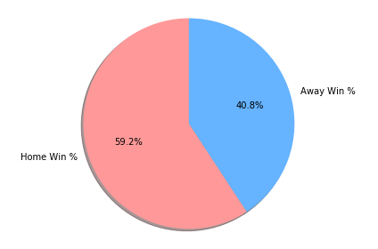

```python
# Pie Chart for the Home Team Advantage
labels = ['Home Win %','Away Win %']
sizes = [home_win_pct,away_win_pct]
colors = ['#ff9999','#66b3ff']
fig1, ax1 = plt.subplots()
ax1.pie(sizes, labels=labels, autopct='%1.1f%%',colors= colors,
        shadow=True, startangle=90)
ax1.axis('equal')
plt.tight_layout()
plt.show()
```

Home team Advantage - Home Team wins 59.2% of the time

```python
# Advantage of Leading the First Half
lead_fhalf = len(df[(df.WIN ==1) & (df.LEAD_FH==1)])
loss_fhalf = len(df[(df.WIN ==1) & (df.LEAD_FH==0)])
tied_fhalf = len(df[(df.WIN ==1) & (df.LEAD_FH==2)])

lead_fhalf_pct = lead_fhalf/total_matches
loss_fhalf_pct = loss_fhalf/total_matches
tied_fhalf_pct = tied_fhalf/total_matches
```

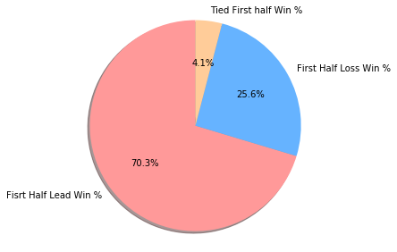

```python
# Pie Chart for the Home Team Advantage
labels = ['Fisrt Half Lead Win %','First Half Loss Win %', 'Tied First half Win %']
sizes = [lead_fhalf_pct,loss_fhalf_pct, tied_fhalf_pct]
colors = ['#ff9999','#66b3ff','#ffcc99']
fig1, ax1 = plt.subplots()
ax1.pie(sizes, labels=labels, autopct='%1.1f%%',colors= colors,
        shadow=True, startangle=90)
ax1.axis('equal')
plt.tight_layout()
plt.show()
```

Team Leading in First Half wins 70.3 % of time  
Futher Analysis on Points Differential in First Half can also be done- which is if teams lead by certain points they are more likely to win

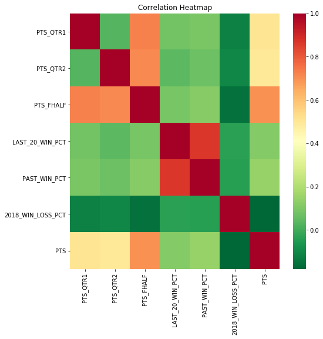

```python
# Plot Correlation among the Factors -QTR1, QTR2, First Half Points,
# Win pct Last season 20 game, win_pct last season, win_pct_this season, final PTS
# I am excluding HOME team and WIN/LOSS parameter, as they are binary, and correlation among binary and non-binray are not good.

df_corr = df[['PTS_QTR1','PTS_QTR2','PTS_FHALF','LAST_20_WIN_PCT','PAST_WIN_PCT','2018_WIN_LOSS_PCT','PTS']]
df_corr_matrix = df_corr.corr()
rcParams['figure.figsize'] = 8,8
instrument_ids = df_corr_matrix.index
m = [0,0.2,0.4,0.6,0.8,1]
seaborn.heatmap(df_corr_matrix, xticklabels=instrument_ids,
                yticklabels=instrument_ids, cmap='RdYlGn_r' )
plt.title('Correlation Heatmap')
    #plt.legend(label='')
plt.show()
```

### Part 1: Logistic Regression Using Only Previous Data Available (No Quater Points)

1) We need to convert the output to 0-1 (Win-Loss), I am converting all Tied to 0  
2) Removing First 100 Rows, as the data for Win% this season would not be ideal for Classification

```python
# For Logistic Regression - We n
df_lr = df.loc[100:]
df_lr = df_lr.replace({'WIN':2},0)
X = df_lr[['HOME_TEAM','LAST_20_WIN_PCT','PAST_WIN_PCT','2018_WIN_LOSS_PCT']]

y = df_lr['WIN']
```

```python
X_train, X_test, y_train, y_test = train_test_split(X, y, test_size=0.3, random_state=0)
logreg = LogisticRegression()
logreg.fit(X_train, y_train)
y_pred = logreg.predict(X_test)
print('Accuracy of logistic regression classifier on test set: {:.2f}'.format(logreg.score(X_test, y_test)))
```

```
Accuracy of logistic regression classifier on test set: 0.66
```

```python
# Precision and Recall of the above classification
print(classification_report(y_test, y_pred))
```

```
              precision    recall  f1-score   support

           0       0.65      0.68      0.67       351
           1       0.67      0.64      0.66       358

    accuracy                           0.66       709
   macro avg       0.66      0.66      0.66       709
weighted avg       0.66      0.66      0.66       709
```

### Part 2: Logistic Regression using Data Upto Half Time

1) Adding Data Source upto Midpoint  
2) Checking if it improves classification

```python
X = df_lr[['HOME_TEAM','LAST_20_WIN_PCT','PAST_WIN_PCT','2018_WIN_LOSS_PCT','PTS_FHALF','HALF_PTS_DIFF']]
y = df_lr['WIN']

X_train, X_test, y_train, y_test = train_test_split(X, y, test_size=0.3, random_state=0)
logreg = LogisticRegression()
logreg.fit(X_train, y_train)
y_pred = logreg.predict(X_test)
print('Accuracy of logistic regression classifier on test set: {:.2f}'.format(logreg.score(X_test, y_test)))
```

```
Accuracy of logistic regression classifier on test set: 0.74
```

```python
print(classification_report(y_test, y_pred))
```

```
              precision    recall  f1-score   support

           0       0.73      0.75      0.74       351
           1       0.75      0.73      0.74       358

    accuracy                           0.74       709
   macro avg       0.74      0.74      0.74       709
weighted avg       0.74      0.74      0.74       709
```

**Analysis** We can find that the results are better than previous classificaiton  
To futher make this model mode robust, we can add Player Stats, and create a more robust feature set based on Gamy Style of team, defence/offence metrics, average factors from previous games, and more in-depth analysis of games played by the team.

### Team Statistics for Season 2018-2019

1) Transform data from Game/Team to Team Summery  
2) Sort the Team by most number of wins for the Season  
3) Find the Mean of QTR points and Other Factors of the Game

```python
df_factor = pd.read_csv('2018-2019_factor.csv',index_col=0)
```

```python
#Transform the Data from Team/Game to Team specific for Number of Wins and Number of Losses

columns = ['WIN','PTS_QTR1','PTS_QTR2','PTS_QTR3','PTS_QTR4','PTS_OT1','PTS_FHALF','PTS_SHALF','PTS']
columns_factor = ['OPP_OREB_PCT','OPP_TOV_PCT','OPP_FTA_RATE','OPP_EFG_PCT','OREB_PCT','TM_TOV_PCT','FTA_RATE','EFG_PCT']
for column in columns:
    df_team[column] = 0
for column in columns_factor:
    df_team[column] = 0
df_team['NO_GAMES'] = 0
for i in range(len(df_team)):
    df_sum = df[df.TEAM_ID == df_team['TEAM_ID'].iloc[i]].sum()
    df_mean_factor =  df_factor[df_factor.TEAM_ID == df_team['TEAM_ID'].iloc[i]].mean()
    for column in columns:
        df_team[column].iloc[i] = df_sum[column]
    for column in columns_factor:
        df_team[column].iloc[i] = df_mean_factor[column]

    df_team['NO_GAMES'].iloc[i] = df[df.TEAM_ID == df_team['TEAM_ID'].iloc[i]].GAME_ID.count()
```

```python
# Assuming not won as Lossing- (Not considering the Tied Games)
df_team['LOSS']     = df_team['NO_GAMES'] - df_team['WIN']
df_team['WIN_PCT']  = df_team['WIN']/df_team['NO_GAMES']
df_team['LOSS_PCT'] = df_team['LOSS']/df_team['NO_GAMES']

# Adding Mean of Points Scored in Half time and Total Points
df_team['PTS_FHALF_MEAN'] = df_team['PTS_FHALF']/df_team['NO_GAMES']
df_team['PTS_MEAN'] = df_team['PTS']/df_team['NO_GAMES']
```

```python
# Simple Table For showing the Ranking of Each Team at the end of Season 2018-2019
df_team = df_team.sort_values(by='WIN', ascending=False)
#df_team = df_team.reset_index()
df_team_abbr = df_team[['TEAM_ID','ABBREVIATION','WIN','WIN_PCT','LOSS','LOSS_PCT','PTS_FHALF_MEAN','PTS_MEAN']]
pd.set_option('expand_frame_repr', True)
df_team_abbr
```

|  | TEAM_ID | ABBREVIATION | WIN | WIN_PCT | LOSS | LOSS_PCT | PTS_FHALF_MEAN | PTS_MEAN |
| --- | --- | --- | --- | --- | --- | --- | --- | --- |
| 0 | 1.610613e+09 | MIL | 60 | 0.731707 | 22 | 0.268293 | 58.780488 | 118.121951 |
| 1 | 1.610613e+09 | TOR | 58 | 0.707317 | 24 | 0.292683 | 57.524390 | 114.439024 |
| 2 | 1.610613e+09 | GSW | 57 | 0.695122 | 25 | 0.304878 | 60.048780 | 117.682927 |
| 3 | 1.610613e+09 | DEN | 54 | 0.658537 | 28 | 0.341463 | 57.134146 | 110.670732 |
| 4 | 1.610613e+09 | HOU | 53 | 0.646341 | 29 | 0.353659 | 58.621951 | 113.914634 |
| 5 | 1.610613e+09 | POR | 53 | 0.646341 | 29 | 0.353659 | 56.695122 | 114.658537 |
| 6 | 1.610613e+09 | PHI | 51 | 0.621951 | 31 | 0.378049 | 59.646341 | 115.182927 |
| 7 | 1.610613e+09 | UTA | 50 | 0.609756 | 32 | 0.390244 | 55.256098 | 111.719512 |
| 8 | 1.610613e+09 | OKC | 49 | 0.597561 | 33 | 0.402439 | 56.878049 | 114.475610 |
| 9 | 1.610613e+09 | BOS | 49 | 0.597561 | 33 | 0.402439 | 55.329268 | 112.390244 |
| 10 | 1.610613e+09 | IND | 48 | 0.585366 | 34 | 0.414634 | 54.902439 | 108.012195 |
| 11 | 1.610613e+09 | SAS | 48 | 0.585366 | 34 | 0.414634 | 55.560976 | 111.658537 |
| 12 | 1.610613e+09 | LAC | 48 | 0.585366 | 34 | 0.414634 | 58.975610 | 115.146341 |
| 13 | 1.610613e+09 | BKN | 42 | 0.512195 | 40 | 0.487805 | 54.207317 | 112.243902 |
| 14 | 1.610613e+09 | ORL | 42 | 0.512195 | 40 | 0.487805 | 54.512195 | 107.317073 |
| 15 | 1.610613e+09 | DET | 41 | 0.500000 | 41 | 0.500000 | 53.451220 | 107.048780 |
| 16 | 1.610613e+09 | SAC | 39 | 0.475610 | 43 | 0.524390 | 57.573171 | 114.182927 |
| 17 | 1.610613e+09 | CHA | 39 | 0.475610 | 43 | 0.524390 | 55.585366 | 110.743902 |
| 18 | 1.610613e+09 | MIA | 39 | 0.475610 | 43 | 0.524390 | 54.109756 | 105.707317 |
| 19 | 1.610613e+09 | LAL | 37 | 0.451220 | 45 | 0.548780 | 56.621951 | 111.768293 |
| 20 | 1.610613e+09 | MIN | 36 | 0.439024 | 46 | 0.560976 | 56.670732 | 112.475610 |
| 21 | 1.610613e+09 | NOP | 33 | 0.402439 | 49 | 0.597561 | 58.378049 | 115.439024 |
| 22 | 1.610613e+09 | MEM | 33 | 0.402439 | 49 | 0.597561 | 53.353659 | 103.536585 |
| 23 | 1.610613e+09 | DAL | 33 | 0.402439 | 49 | 0.597561 | 56.073171 | 108.865854 |
| 24 | 1.610613e+09 | WAS | 32 | 0.390244 | 50 | 0.609756 | 56.963415 | 114.024390 |
| 25 | 1.610613e+09 | ATL | 29 | 0.353659 | 53 | 0.646341 | 57.902439 | 113.341463 |
| 26 | 1.610613e+09 | CHI | 22 | 0.268293 | 60 | 0.731707 | 51.500000 | 104.939024 |
| 27 | 1.610613e+09 | PHX | 19 | 0.231707 | 63 | 0.768293 | 52.926829 | 107.500000 |
| 28 | 1.610613e+09 | CLE | 19 | 0.231707 | 63 | 0.768293 | 51.756098 | 104.475610 |
| 29 | 1.610613e+09 | NYK | 17 | 0.207317 | 65 | 0.792683 | 52.573171 | 104.573171 |

```python
df_team_factor = df_team[['TEAM_ID','ABBREVIATION','WIN_PCT','OREB_PCT','TM_TOV_PCT','FTA_RATE','EFG_PCT']]
df_team_factor
```

|  | TEAM_ID | ABBREVIATION | WIN_PCT | OREB_PCT | TM_TOV_PCT | FTA_RATE | EFG_PCT |
| --- | --- | --- | --- | --- | --- | --- | --- |
| 0 | 1.610613e+09 | MIL | 0.731707 | 0.181537 | 0.131012 | 0.256476 | 0.550768 |
| 1 | 1.610613e+09 | TOR | 0.707317 | 0.191378 | 0.135598 | 0.249098 | 0.546012 |
| 2 | 1.610613e+09 | GSW | 0.695122 | 0.203390 | 0.137878 | 0.229768 | 0.565073 |
| 3 | 1.610613e+09 | DEN | 0.658537 | 0.233866 | 0.132963 | 0.233707 | 0.528305 |
| 4 | 1.610613e+09 | HOU | 0.646341 | 0.198756 | 0.131841 | 0.283720 | 0.543305 |
| 5 | 1.610613e+09 | POR | 0.646341 | 0.232707 | 0.134695 | 0.259512 | 0.530451 |
| 6 | 1.610613e+09 | PHI | 0.621951 | 0.216329 | 0.142671 | 0.318793 | 0.533159 |
| 7 | 1.610613e+09 | UTA | 0.609756 | 0.201659 | 0.146817 | 0.296512 | 0.538805 |
| 8 | 1.610613e+09 | OKC | 0.597561 | 0.226280 | 0.131329 | 0.268207 | 0.515256 |
| 9 | 1.610613e+09 | BOS | 0.597561 | 0.193354 | 0.125476 | 0.217537 | 0.535268 |
| 10 | 1.610613e+09 | IND | 0.585366 | 0.190841 | 0.135683 | 0.245549 | 0.530805 |
| 11 | 1.610613e+09 | SAS | 0.585366 | 0.189780 | 0.120329 | 0.239817 | 0.535732 |
| 12 | 1.610613e+09 | LAC | 0.585366 | 0.196927 | 0.138329 | 0.330793 | 0.529195 |
| 13 | 1.610613e+09 | BKN | 0.512195 | 0.206110 | 0.143585 | 0.288220 | 0.520817 |
| 14 | 1.610613e+09 | ORL | 0.512195 | 0.196463 | 0.130829 | 0.217951 | 0.518366 |
| 15 | 1.610613e+09 | DET | 0.500000 | 0.217988 | 0.136829 | 0.264146 | 0.509866 |
| 16 | 1.610613e+09 | SAC | 0.475610 | 0.207866 | 0.126585 | 0.247256 | 0.525232 |
| 17 | 1.610613e+09 | CHA | 0.475610 | 0.191329 | 0.119146 | 0.260707 | 0.515390 |
| 18 | 1.610613e+09 | MIA | 0.475610 | 0.215488 | 0.145500 | 0.249305 | 0.516415 |
| 19 | 1.610613e+09 | LAL | 0.451220 | 0.196793 | 0.147268 | 0.259841 | 0.527927 |
| 20 | 1.610613e+09 | MIN | 0.439024 | 0.213902 | 0.126280 | 0.269439 | 0.512720 |
| 21 | 1.610613e+09 | NOP | 0.402439 | 0.214988 | 0.139268 | 0.257573 | 0.530549 |
| 22 | 1.610613e+09 | MEM | 0.402439 | 0.176354 | 0.140378 | 0.274890 | 0.509159 |
| 23 | 1.610613e+09 | DAL | 0.402439 | 0.198366 | 0.139073 | 0.296122 | 0.519902 |
| 24 | 1.610613e+09 | WAS | 0.390244 | 0.187793 | 0.133573 | 0.268780 | 0.531512 |
| 25 | 1.610613e+09 | ATL | 0.353659 | 0.219354 | 0.158573 | 0.258061 | 0.522695 |
| 26 | 1.610613e+09 | CHI | 0.268293 | 0.173378 | 0.137805 | 0.238122 | 0.506000 |
| 27 | 1.610613e+09 | PHX | 0.231707 | 0.180671 | 0.150488 | 0.261634 | 0.515195 |
| 28 | 1.610613e+09 | CLE | 0.231707 | 0.208354 | 0.135268 | 0.238976 | 0.503976 |
| 29 | 1.610613e+09 | NYK | 0.207317 | 0.196951 | 0.136976 | 0.273085 | 0.490622 |

### Future Work

1) More Custom Feature Set for Win Predictibilty- Based on Player Stats and the play style of Team  
2) Previous Season Data can be explored for more robust Feature Set  
3) Better Visualization of Stats (Team, PLayer, Overall Structure of Game) 4) Using Clustering - Players can be clustered into different catogories